# Technical Report

5666193

2024-12-20

This is to certify that the work I am submitting is my own. All external references and sources are clearly acknowledged and identified within the contents. I am aware of the University of Warwick regulation concerning plagiarism and collusion.

No substantial part(s) of the work submitted here has also been submitted by me in other assessments for accredited courses of study, and I acknowledge that if this has been done an appropriate reduction in the mark I might otherwise have received will be made.

AI was used in the preparation of this work. It was used in the development of the code: It was used to provide example uses of functions or approaches to elements of the challenges which were then interpreted by me and modified to be applicable to this data/report.

# **Project 1**

### *Importing libraries*

```r
knitr::opts_chunk$set(echo = TRUE, warning = FALSE)
library(tidyverse)
library(Hmisc)
library(dplyr)
library(gridExtra)
library(kableExtra)
```

### *Data Dictionary*

This data from various datasets from the UK Office for National Statistics. Here is a summary of the variables

| *Variables* | *Description* |
| --- | --- |
| area_name | Name of the Local region |
| area_code | Unique code of the area |
| Population | Population of the area |
| Poverty | Proportion of population living in poverty |
| CVD | % of people who experienced Cardiovascular Disease (CVD) |
| Overweight | Proportion of population who are overweight |
| Smoker | Proportion of population who smokes |
| Wellbeing | Average Wellbeing score of people living in the area |

### *Read Data*

Load data using `read_csv`

```r
disease_data <- read_csv('C:\\Users\\Ridhi\\Desktop\\Business stats\\Cardio_Vascular_Disease.csv')
```

### *Data Quality checks*

Check the structure of the data

```r
str(disease_data)
```

```
## spc_tbl_ [385 × 8] (S3: spec_tbl_df/tbl_df/tbl/data.frame)
##  $ area_name : chr [1:385] "Hartlepool" "Middlesbrough" "Redcar and Cleveland" "Stockton-on-Tees" ...
##  $ area_code : chr [1:385] "E06000001" "E06000002" "E06000003" "E06000004" ...
##  $ Population: num [1:385] 88905 133375 131035 186365 104300 ...
##  $ Poverty   : num [1:385] 23 25.1 21.4 19.5 19.7 21.9 17.9 24.9 26.1 22.4 ...
##  $ CVD       : num [1:385] 13.7 13.1 15 12.4 11.9 15.7 12 13.4 17.6 11.2 ...
##  $ overweight: num [1:385] 34.6 32 33.4 40.2 35.7 ...
##  $ smokers   : num [1:385] 17.3 17.9 13.3 12.5 10.6 13.2 10 15.5 20.6 22 ...
##  $ wellbeing : num [1:385] 7.33 7.21 7.44 7.4 7.25 7.29 7.21 7.43 7.16 7.14 ...
##  - attr(*, "spec")=
##   .. cols(
##   ..   area_name = col_character(),
##   ..   area_code = col_character(),
##   ..   Population = col_double(),
##   ..   Poverty = col_double(),
##   ..   CVD = col_double(),
##   ..   overweight = col_double(),
##   ..   smokers = col_double(),
##   ..   wellbeing = col_double()
##   .. )
##  - attr(*, "problems")=<externalptr>
```

Look for duplicates in area_name

```r
sum(duplicated(disease_data$area_name))
```

```
## [1] 0
```

There are no duplicate values in the area name column

Check for missing values

```r
disease_data %>%
  summarise_all(~sum(is.na(.)))
```

```
## # A tibble: 1 × 8
##   area_name area_code Population Poverty   CVD overweight smokers wellbeing
##       <int>     <int>      <int>   <int> <int>      <int>   <int>     <int>
## 1         0         0         76      76    76         72       7        15
```

Since we are comparing CVD against other metrics, the best approach is to remove the null values of our y axis (i.e., CVD)

```r
clean_data <- disease_data[!is.na(disease_data$CVD), ]
clean_data %>%
  summarise_all(~sum(is.na(.)))
```

```
## # A tibble: 1 × 8
##   area_name area_code Population Poverty   CVD overweight smokers wellbeing
##       <int>     <int>      <int>   <int> <int>      <int>   <int>     <int>
## 1         0         0          0       0     0          0       3         4
```

Removed NA rows in `CVD` and on checking there are still NA values in `smokers` and `wellbeing`.

Imputing those NA values with the median of the columns.

```r
smokers_mean_value <- median(clean_data$smokers, na.rm = TRUE)
wellbeing_mean_value <- median(clean_data$wellbeing, na.rm = TRUE)

clean_data$smokers[is.na(clean_data$smokers)] <- smokers_mean_value
clean_data$wellbeing[is.na(clean_data$wellbeing)] <- wellbeing_mean_value
```

- Imputation was preferred over removing Na values, as 76 rows were already removed due to missing values in the dependent variable (CVD) and the dataset originally had only 385 rows, removing additional 7 rows felt excessive as it would result in further data loss.
- Imputed the NA values with median because it is less sensitive to outliers and helps avoid introducing bias in the dataset.
- Another way to deal with Na values could be to ask Subject Matter Experts.

```r
#summary data
summary_table <- summary(clean_data)
```

Table 1: Summary of CVD in England

|  | area_name | area_code | Population | Poverty | CVD | overweight | smokers | wellbeing |
| --- | --- | --- | --- | --- | --- | --- | --- | --- |
|  | Length:309 | Length:309 | Min. : 1960 | Min. :12.90 | Min. : 7.90 | Min. :10.24 | Min. : 3.20 | Min. :6.610 |
|  | Class :character | Class :character | 1st Qu.: 100640 | 1st Qu.:16.90 | 1st Qu.:10.90 | 1st Qu.:21.63 | 1st Qu.:10.50 | 1st Qu.:7.280 |
|  | Mode :character | Mode :character | Median : 135275 | Median :18.70 | Median :12.30 | Median :25.63 | Median :12.55 | Median :7.410 |
|  | NA | NA | Mean : 174804 | Mean :19.34 | Mean :12.42 | Mean :25.55 | Mean :12.85 | Mean :7.418 |
|  | NA | NA | 3rd Qu.: 216600 | 3rd Qu.:21.40 | 3rd Qu.:14.10 | 3rd Qu.:29.46 | 3rd Qu.:15.20 | 3rd Qu.:7.540 |
|  | NA | NA | Max. :1056970 | Max. :30.70 | Max. :17.80 | Max. :40.22 | Max. :27.80 | Max. :8.100 |

There are some outliers in `population` however, we are not doing anything about it because we are not using it directly in our analysis.

### *Including Plots*

Histogram to check the data distribution

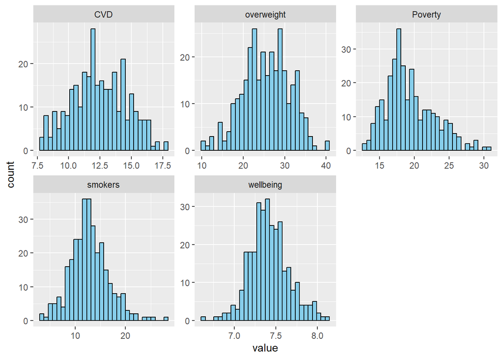

The histogram shows the distribution of five continuous variables: Poverty, CVD, overweight, smokers and wellbeing.

Boxplot to check the outliers

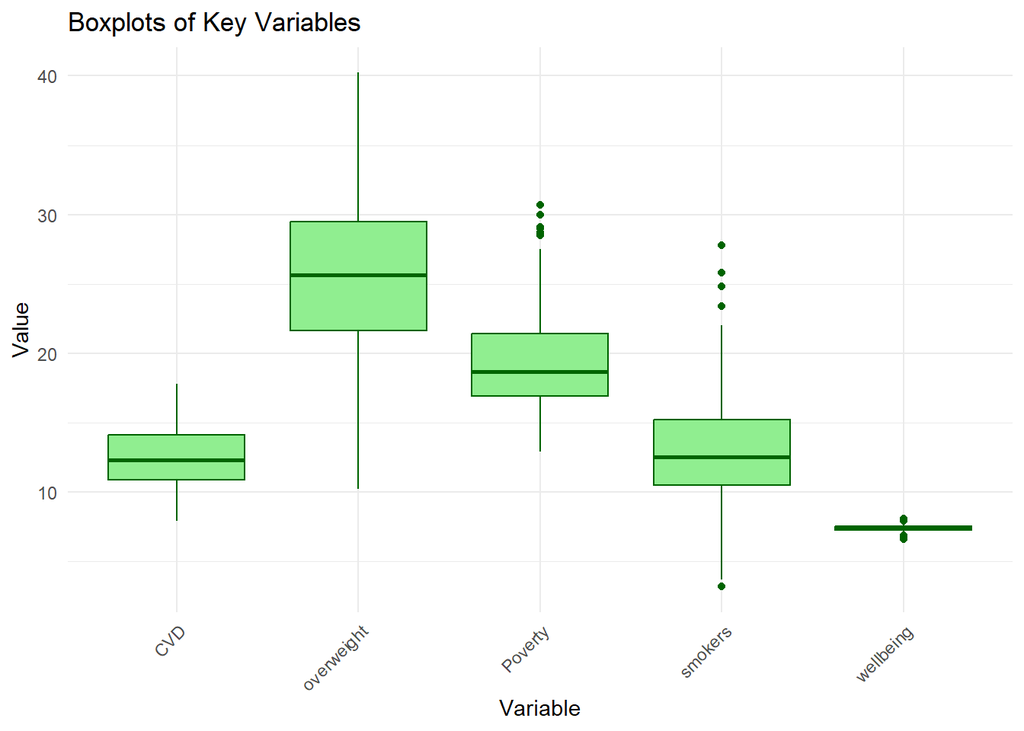

```r
clean_data %>%
  select(Poverty, CVD, overweight, smokers, wellbeing) %>%
  gather() %>%
  ggplot(aes(x = key, y = value)) +
    geom_boxplot(fill = "lightgreen", color = "darkgreen") +
    labs(title = "Boxplots of Key Variables",
         x = "Variable",
         y = "Value") +
    theme_minimal() +
    theme(axis.text.x = element_text(angle = 45, hjust = 1))
```

- There are outliers in `smokers` and `Poverty`. `Wellbeing` has data values with a low variance i.e., the data values are tightly clustered.
- The outliers were not removed for the analysis because they could contain valuable insights and removing them could risk losing important variability in the data, potentially skewing the results and not accurately representing the full range of possible outcomes.

Checking the relationship of *Poverty*, *Wellbeing*, *Smokers* and *Overweight* with *CVD*.

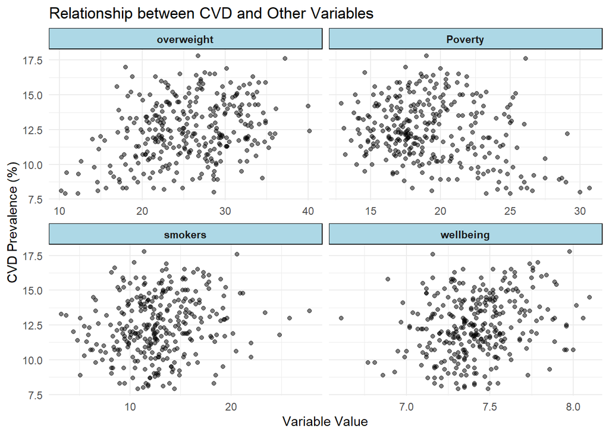

```r
data_long <- pivot_longer(clean_data,
                          cols = c(overweight, Poverty, wellbeing, smokers),
                          names_to = "variable",
                          values_to = "value")

ggplot(data_long, aes(x = value, y = CVD)) +
  geom_point(alpha = 0.5) +
  facet_wrap(~ variable, scales = "free_x") +
  labs(title = "Relationship between CVD and Other Variables",
       x = "Variable Value",
       y = "CVD Prevalence (%)") +
  theme_minimal() +
  theme(strip.background = element_rect(fill = "lightblue"),
        strip.text = element_text(face = "bold"))
```

Overweight and Wellbeing have a clear positive relationship with CVD. However, there is a negative linear relationship between CVD and Poverty, suggesting that as poverty rate increases, the prevalence of CVD tends to decrease. This can be further proved by making a correlation matrix.

### *Statistical Tests*

- **Correlation**

Using Pearson correlation because the data is linear and moslty normal

```r
rcorr(as.matrix(clean_data %>% select(Poverty, CVD, overweight, smokers, wellbeing)))
```

```
##            Poverty   CVD overweight smokers wellbeing
## Poverty       1.00 -0.24       0.15    0.36     -0.34
## CVD          -0.24  1.00       0.32    0.16      0.24
## overweight    0.15  0.32       1.00    0.39     -0.04
## smokers       0.36  0.16       0.39    1.00     -0.20
## wellbeing    -0.34  0.24      -0.04   -0.20      1.00
##
## n= 309
##
##
## P
##            Poverty CVD    overweight smokers wellbeing
## Poverty            0.0000 0.0103     0.0000  0.0000
## CVD        0.0000         0.0000     0.0042  0.0000
## overweight 0.0103  0.0000            0.0000  0.4820
## smokers    0.0000  0.0042 0.0000             0.0005
## wellbeing  0.0000  0.0000 0.4820     0.0005
```

After plotting the relationship graphs of CVD with other variables, a correlation matrix was computed to quantify and validate the association of CVD with other variables.

The Pearson correlation revealed a weak negative correlation between CVD and poverty ($ρ = -0.24$,$p = 0.00$), suggesting that regions with higher poverty levels tend to report lower CVD prevalence. CVD showed weak but statistically significant positive correlations with overweight prevalence (ρ=0.32, p = 0.00), smokers (ρ=0.16, p = 0.0042) and wellbeing (ρ=0.24, p=0.00).

- **Multiple regression**

```r
m.CVD_all <- lm(CVD ~ Poverty + overweight + smokers + wellbeing, data = clean_data)

# Summary of the model
summary(m.CVD_all)
```

```
##
## Call:
## lm(formula = CVD ~ Poverty + overweight + smokers + wellbeing,
##     data = clean_data)
##
## Residuals:
##     Min      1Q  Median      3Q     Max
## -4.4023 -1.4058 -0.1036  1.4290  4.7749
##
## Coefficients:
##             Estimate Std. Error t value Pr(>|t|)
## (Intercept) -1.40976    3.94659  -0.357 0.721183
## Poverty     -0.18048    0.03518  -5.131 5.15e-07 ***
## overweight   0.11290    0.02100   5.375 1.53e-07 ***
## smokers      0.10815    0.03308   3.269 0.001203 **
## wellbeing    1.75948    0.49302   3.569 0.000417 ***
## ---
## Signif. codes:  0 '***' 0.001 '**' 0.01 '*' 0.05 '.' 0.1 ' ' 1
##
## Residual standard error: 1.903 on 304 degrees of freedom
## Multiple R-squared:  0.2394, Adjusted R-squared:  0.2294
## F-statistic: 23.92 on 4 and 304 DF,  p-value: < 2.2e-16
```

```r
#Confidence interval
confint(m.CVD_all)
```

```
##                   2.5 %     97.5 %
## (Intercept) -9.17584910  6.3563352
## Poverty     -0.24969643 -0.1112583
## overweight   0.07156549  0.1542260
## smokers      0.04304818  0.1732430
## wellbeing    0.78932432  2.7296425
```

Whereas Poverty has a significant negative effect upon CVD ($b=-0.18$,$CI=[-0.25, -0.11]$,$t(304)=-5.13$,$p<0.001$) This calls for further investigation.

- **Interaction Regression**

```r
# Interaction regression model
pov.over.int.lm <- lm(CVD ~ Poverty * overweight, data = clean_data)

# Summary of the model
summary(pov.over.int.lm)
```

```
##
## Call:
## lm(formula = CVD ~ Poverty * overweight, data = clean_data)
##
## Residuals:
##     Min      1Q  Median      3Q     Max
## -4.4650 -1.4438 -0.2586  1.3720  5.2332
##
## Coefficients:
##                     Estimate Std. Error t value Pr(>|t|)
## (Intercept)        20.829507   2.849296   7.310 2.35e-12 ***
## Poverty            -0.597837   0.139246  -4.293 2.37e-05 ***
## overweight         -0.211048   0.116612  -1.810  0.07131 .
## Poverty:overweight  0.017203   0.005649   3.045  0.00253 **
## ---
## Signif. codes:  0 '***' 0.001 '**' 0.01 '*' 0.05 '.' 0.1 ' ' 1
##
## Residual standard error: 1.937 on 305 degrees of freedom
## Multiple R-squared:  0.2098, Adjusted R-squared:  0.202
## F-statistic:    27 on 3 and 305 DF,  p-value: 1.64e-15
```

```r
#confidence interval of the model
confint(pov.over.int.lm)
```

```
##                           2.5 %      97.5 %
## (Intercept)        15.222740326 26.43627354
## Poverty            -0.871842241 -0.32383158
## overweight         -0.440513277  0.01841825
## Poverty:overweight  0.006086634  0.02832030
```

```r
# Interaction regression model
pov.smokers.int.lm <- lm(CVD ~ Poverty * smokers, data = clean_data)

# Summary of the model
summary(pov.smokers.int.lm)
```

```
##
## Call:
## lm(formula = CVD ~ Poverty * smokers, data = clean_data)
##
## Residuals:
##    Min     1Q Median     3Q    Max
## -5.180 -1.472 -0.272  1.447  5.573
##
## Coefficients:
##                  Estimate Std. Error t value Pr(>|t|)
## (Intercept)     16.740733   2.374658   7.050  1.2e-11 ***
## Poverty         -0.332055   0.122988  -2.700  0.00732 **
## smokers         -0.014624   0.185210  -0.079  0.93712
## Poverty:smokers  0.009059   0.009252   0.979  0.32828
## ---
## Signif. codes:  0 '***' 0.001 '**' 0.01 '*' 0.05 '.' 0.1 ' ' 1
##
## Residual standard error: 2.028 on 305 degrees of freedom
## Multiple R-squared:  0.1335, Adjusted R-squared:  0.125
## F-statistic: 15.67 on 3 and 305 DF,  p-value: 1.679e-09
```

```r
#confidence interval of the model
confint(pov.smokers.int.lm)
```

```
##                        2.5 %      97.5 %
## (Intercept)     12.067946785 21.41352021
## Poverty         -0.574067768 -0.09004146
## smokers         -0.379075160  0.34982690
## Poverty:smokers -0.009146287  0.02726392
```

```r
# Interaction regression model
pov.wellbeing.int.lm <- lm(CVD ~ Poverty * wellbeing, data = clean_data)

# Summary of the model
summary(pov.wellbeing.int.lm)
```

```
##
## Call:
## lm(formula = CVD ~ Poverty * wellbeing, data = clean_data)
##
## Residuals:
##     Min      1Q  Median      3Q     Max
## -4.2761 -1.5712 -0.2624  1.5714  6.4364
##
## Coefficients:
##                   Estimate Std. Error t value Pr(>|t|)
## (Intercept)       11.34296   22.38718   0.507    0.613
## Poverty           -0.58318    1.15522  -0.505    0.614
## wellbeing          0.43253    3.03575   0.142    0.887
## Poverty:wellbeing  0.06392    0.15728   0.406    0.685
##
## Residual standard error: 2.081 on 305 degrees of freedom
## Multiple R-squared:  0.08794,    Adjusted R-squared:  0.07897
## F-statistic: 9.802 on 3 and 305 DF,  p-value: 3.427e-06
```

```r
#confidence interval of the model
confint(pov.wellbeing.int.lm)
```

```
##                         2.5 %     97.5 %
## (Intercept)       -32.7099159 55.3958450
## Poverty            -2.8563923  1.6900324
## wellbeing          -5.5411398  6.4062086
## Poverty:wellbeing  -0.2455801  0.3734153
```

To sum up the interaction regression models, it explores the relationship of CVD and poverty with Overweight prevalence, Smoker rate and Average Wellbeing of people. It showed that the interaction of poverty and overweight was statistically significant ($p=0.002$), meaning that the link between poverty and CVD rates depends on overweight levels. However, the interactions of poverty with smoking and wellbeing were not significant ($p>0.05$), suggesting that these factors don’t have the same moderating effect on poverty-CVD relationship.

## Graph representing relationship between CVD and Poverty

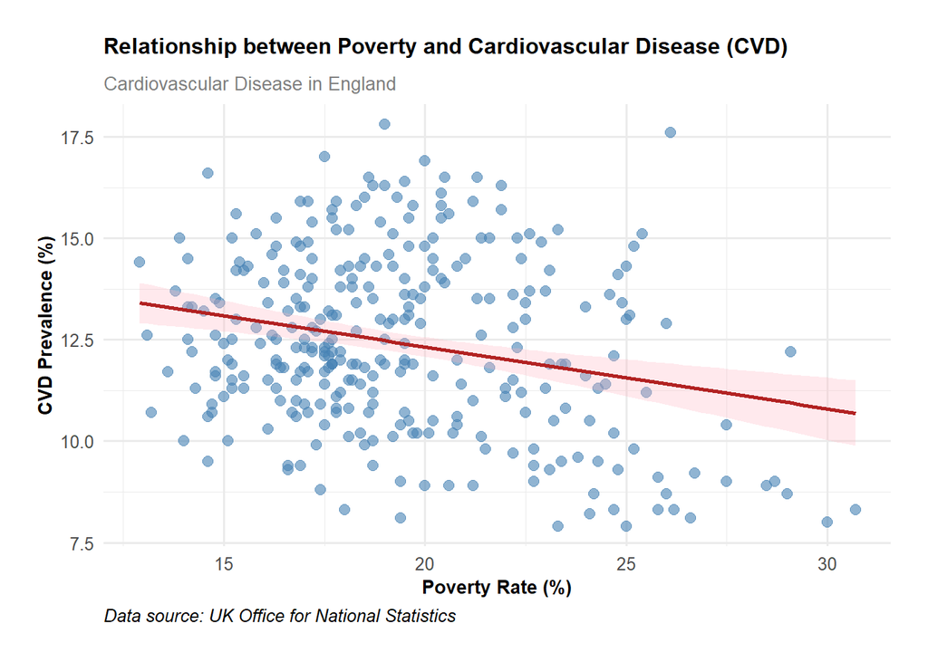

```r
ggplot(clean_data, aes(x = Poverty, y = CVD)) +
  geom_point(alpha = 0.6, color = "steelblue", size=2.5) +
  geom_smooth(method = "lm", se = TRUE, color = "firebrick", fill = "lightpink", alpha = 0.3) +
  scale_color_viridis_c(option = "magma") +
  labs(title = "Relationship between Poverty and Cardiovascular Disease (CVD)",
       subtitle = "Cardiovascular Disease in England",
       x = "Poverty Rate (%)",
       y = "CVD Prevalence (%)",
       caption = "Data source: UK Office for National Statistics") +
  theme_minimal(base_size = 12) +
  theme(
        plot.title = element_text(face = "bold", size = 12, margin = margin(b = 10)),
        plot.subtitle = element_text(size = 10, color = "gray50"),
        axis.title = element_text(face = "bold", size = 10),
        plot.caption = element_text(hjust = 0, face = "italic"),
        plot.margin = margin(t = 20, r = 20, b = 20, l = 20, unit = "pt"))
```

# **Project 2**

### *Data Dictionary*

This data contains information on customer satisfaction from a Furniture retail company, where each row corresponds to a single store. Here is a summary of the variables within the dataset.

| *Variables* | *Description* |
| --- | --- |
| SES_category | Company’s categorization of store type by local Socio-Economic-Status |
| customer.satisfaction | Average customer score |
| staff.satisfaction | Average staff satisfaction score |
| delivery.time | Average delivery time of large and custom items |
| new_range | whether the store carries new range of products |

### *Read Data*

Load data using `read_csv`

```r
cust_data <- read_csv('C:\\Users\\Ridhi\\Desktop\\Business stats\\cust_satisfaction.csv')
```

### *Data Quality checks*

Check the structure of the data

```r
str(cust_data)
```

```
## spc_tbl_ [300 × 5] (S3: spec_tbl_df/tbl_df/tbl/data.frame)
##  $ SES_category         : chr [1:300] "Medium" "Medium" "Medium" "High" ...
##  $ customer.satisfaction: num [1:300] 7.27 7.93 7.12 6.35 6.78 ...
##  $ staff.satisfaction   : num [1:300] 6.88 7.44 7.15 6.47 7.06 ...
##  $ delivery.time        : num [1:300] 66.7 68.2 70.7 61.4 57.7 ...
##  $ new_range            : logi [1:300] FALSE FALSE FALSE TRUE TRUE TRUE ...
##  - attr(*, "spec")=
##   .. cols(
##   ..   SES_category = col_character(),
##   ..   customer.satisfaction = col_double(),
##   ..   staff.satisfaction = col_double(),
##   ..   delivery.time = col_double(),
##   ..   new_range = col_logical()
##   .. )
##  - attr(*, "problems")=<externalptr>
```

Check for missing values

```r
cust_data %>%
  summarise_all(~sum(is.na(.)))
```

```
## # A tibble: 1 × 5
##   SES_category customer.satisfaction staff.satisfaction delivery.time new_range
##          <int>                 <int>              <int>         <int>     <int>
## 1            0                     0                  0             0         0
```

There are no missing values in this dataset.

```r
#summary data
cust_summary <- summary(cust_data)
```

Table 2: Summary of Furniture retail store

|  | SES_category | customer.satisfaction | staff.satisfaction | delivery.time | new_range |
| --- | --- | --- | --- | --- | --- |
|  | Length:300 | Min. :3.760 | Min. :4.850 | Min. :32.96 | Mode :logical |
|  | Class :character | 1st Qu.:6.099 | 1st Qu.:6.216 | 1st Qu.:52.46 | FALSE:142 |
|  | Mode :character | Median :7.006 | Median :6.634 | Median :60.45 | TRUE :158 |
|  | NA | Mean :6.930 | Mean :6.751 | Mean :59.60 | NA |
|  | NA | 3rd Qu.:7.865 | 3rd Qu.:7.274 | 3rd Qu.:66.79 | NA |
|  | NA | Max. :9.670 | Max. :8.860 | Max. :92.48 | NA |

### *Including Plots*

Histogram to check the data distribution

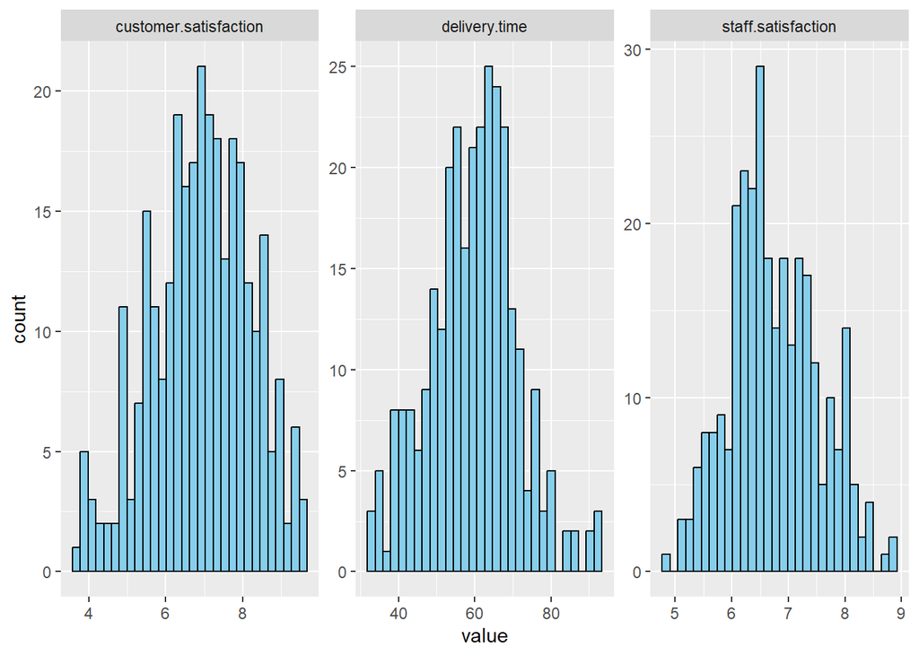

The histogram shows the distribution of three continuous variables: customer.satisfaction, delivery.time and staff.satisfaction.

Boxplot to check the outliers.

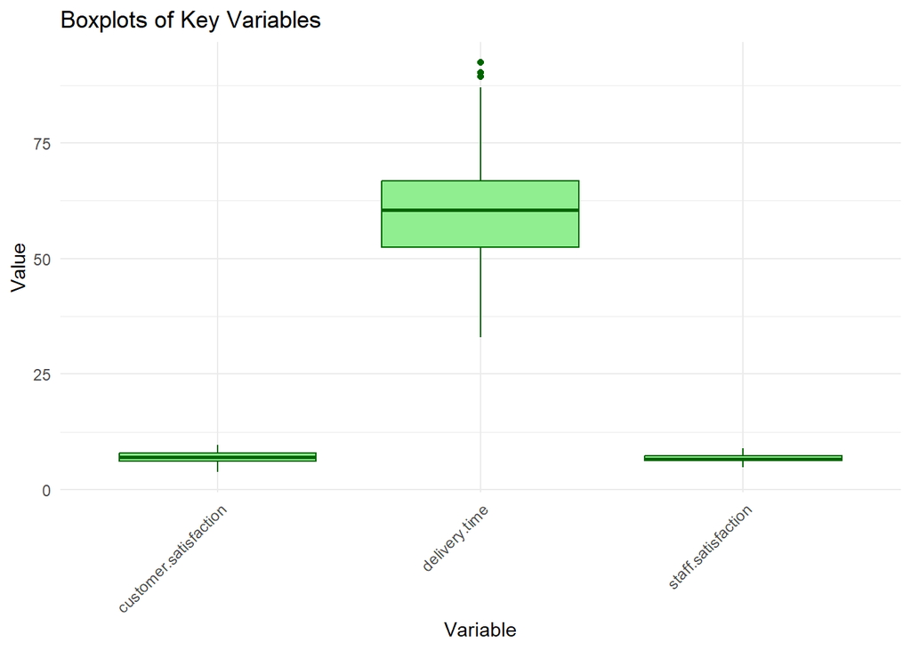

```r
cust_data %>%
  select(customer.satisfaction, staff.satisfaction, delivery.time) %>%
  gather() %>%
  ggplot(aes(x = key, y = value)) +
    geom_boxplot(fill = "lightgreen", color = "darkgreen") +
    labs(title = "Boxplots of Key Variables",
         x = "Variable",
         y = "Value") +
    theme_minimal() +
    theme(axis.text.x = element_text(angle = 45, hjust = 1))
```

There are outliers in `delivery time`. `Customer satisfaction` and `staff satisfaction` have data values with a low variance i.e., the data values are tightly clustered.

Checking the distribution of *new range*

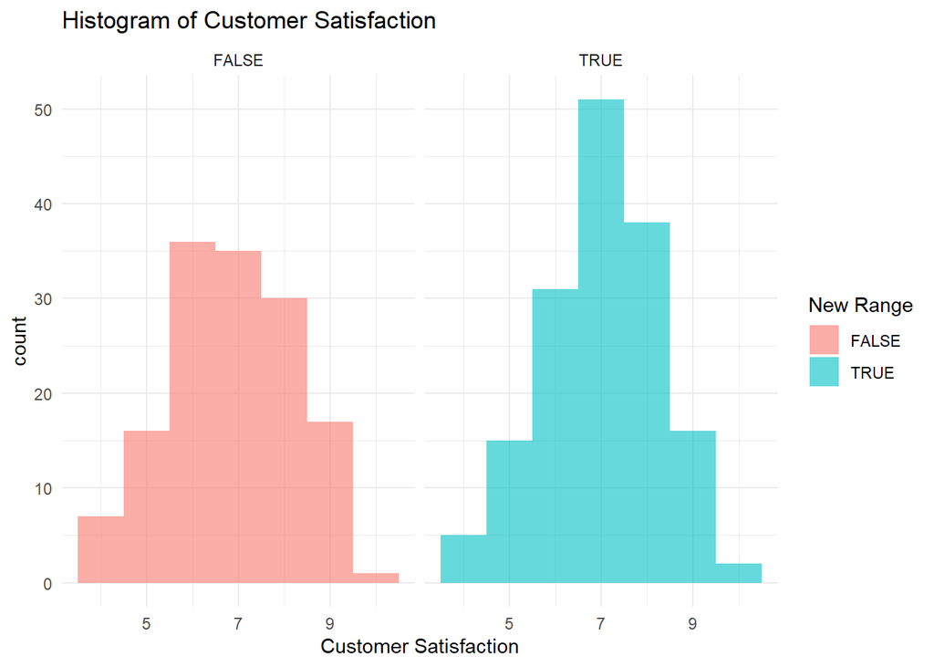

```r
ggplot(cust_data, aes(x = customer.satisfaction, fill = as.factor(new_range))) +
  geom_histogram(alpha = 0.6, position = "identity", binwidth = 1) +
  facet_wrap(~ new_range) +
  labs(title = "Histogram of Customer Satisfaction",
       x = "Customer Satisfaction",
       fill = "New Range") +
  theme_minimal()
```

The stores with `new range` of products appears normally distributed.

Visualizing the relationship between *customer satisfaction* and *new range*.

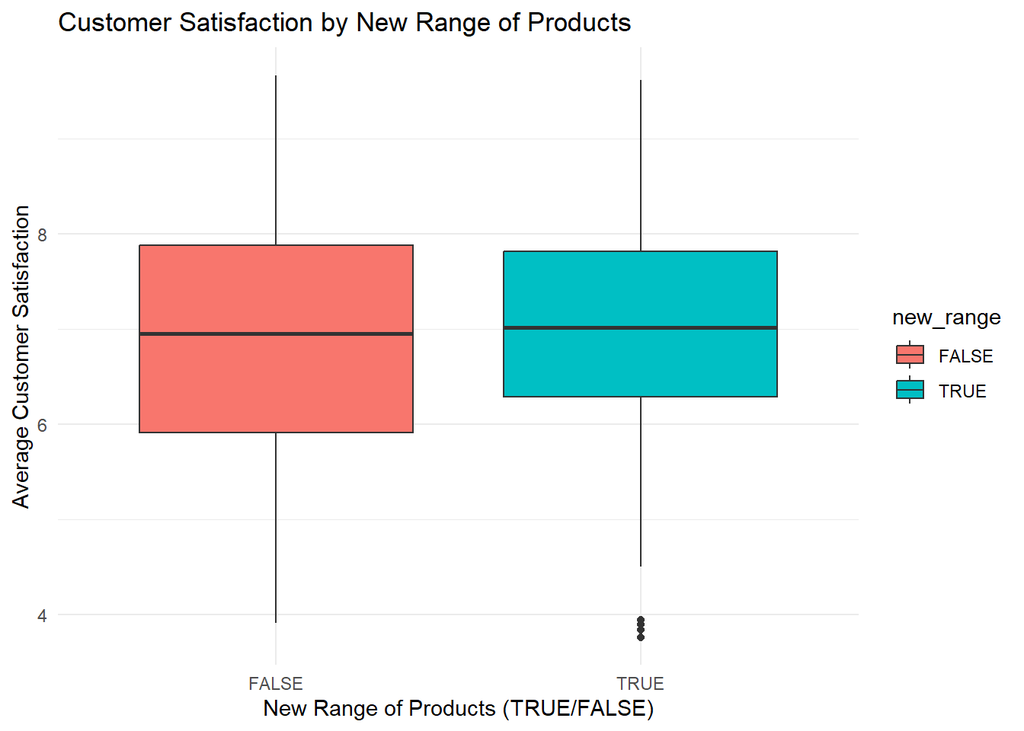

```r
ggplot(cust_data, aes(x = new_range, y = customer.satisfaction, fill = new_range)) +
    geom_boxplot() +
    labs(title = "Customer Satisfaction by New Range of Products",
         x = "New Range of Products (TRUE/FALSE)",
         y = "Average Customer Satisfaction") +
    theme_minimal()
```

This graph further proves that the customer satisfaction scores is similar for stores with and without the new range of products.

For stores without the new range (`FALSE`), customer satisfaction range from 4 to 10. For stores with the new range (`True`), scores range slightly higher, from 4.5 to 10. In both cases, the median score (the middle value) is approximately 7, indicating that half the stores in each group have scores below 7 and half above.

This similarity in the range and median suggests that introducing a new range of products has little to no noticeable effect on customer satisfaction.

Boxplot to check for differences in Median and spread of *SES category* and *customer satisfaction*

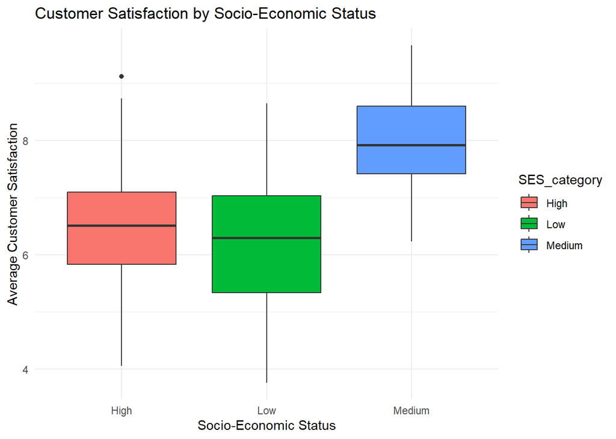

```r
ggplot(cust_data, aes(x = SES_category, y = customer.satisfaction, fill = SES_category)) +
    geom_boxplot() +
    labs(
        title = "Customer Satisfaction by Socio-Economic Status",
        x = "Socio-Economic Status",
        y = "Average Customer Satisfaction"
    ) +
    theme_minimal()
```

This graph shows the distribution of `customer.satisfaction` scores across three socio-economic status (SES) categories: Low, Medium, High.

The general trends indicates that customers from stores in medium SES areas are generally the most satisfied, followed by High SES. With stores categorized as Low SES generally see least satisfied customers.

### *Statistical tests*

- **Correlation Analysis**

Checking the correlation of continuous variables.

```r
rcorr(as.matrix(cust_data[sapply(cust_data, is.numeric)]))
```

```
##                       customer.satisfaction staff.satisfaction delivery.time
## customer.satisfaction                  1.00               0.45         -0.26
## staff.satisfaction                     0.45               1.00         -0.07
## delivery.time                         -0.26              -0.07          1.00
##
## n= 300
##
##
## P
##                       customer.satisfaction staff.satisfaction delivery.time
## customer.satisfaction                       0.0000             0.0000
## staff.satisfaction    0.0000                                   0.2602
## delivery.time         0.0000                0.2602
```

The pearson correlation revealed a weak positive correlation between `customer.satisfaction` and `staff.satisfaction` ($ρ=0.45$, $p=0.00$), suggesting that the stores where the staff is happy has a higher chance of having satisfied customers.

However, there is a weak negative correlation between `customer.satisfaction` and `delivery.time` ($ρ=-0.26$, $p=0.00$), indicating that customer’s are less satisfied as delivery time gets longer.

- **$t$-test**

Checking the effect of *New range* on *customer satisfaction*

```r
cus.satis.newrange <- t.test(customer.satisfaction ~ new_range, data = cust_data)
cus.satis.newrange
```

```
##
##  Welch Two Sample t-test
##
## data:  customer.satisfaction by new_range
## t = -0.86586, df = 290.29, p-value = 0.3873
## alternative hypothesis: true difference in means between group FALSE and group TRUE is not equal to 0
## 95 percent confidence interval:
##  -0.4247351  0.1652029
## sample estimates:
## mean in group FALSE  mean in group TRUE
##            6.861470            6.991236
```

This suggests that the average score for new range -0.13 95% $CI[-0.42, 0.16]$.

- **Linear regression**
1. Effect of *delivery time* on *customer satisfaction*

```r
del.cust.satis.lm <- lm(customer.satisfaction ~ delivery.time, data = cust_data)
summary(del.cust.satis.lm)
```

```
##
## Call:
## lm(formula = customer.satisfaction ~ delivery.time, data = cust_data)
##
## Residuals:
##     Min      1Q  Median      3Q     Max
## -3.3116 -0.8250 -0.0391  0.9266  2.5165
##
## Coefficients:
##                Estimate Std. Error t value Pr(>|t|)
## (Intercept)    8.654405   0.379637  22.797  < 2e-16 ***
## delivery.time -0.028937   0.006254  -4.627 5.54e-06 ***
## ---
## Signif. codes:  0 '***' 0.001 '**' 0.01 '*' 0.05 '.' 0.1 ' ' 1
##
## Residual standard error: 1.25 on 298 degrees of freedom
## Multiple R-squared:  0.06703,    Adjusted R-squared:  0.0639
## F-statistic: 21.41 on 1 and 298 DF,  p-value: 5.539e-06
```

```r
confint(del.cust.satis.lm)
```

```
##                     2.5 %      97.5 %
## (Intercept)    7.90729598  9.40151402
## delivery.time -0.04124463 -0.01662984
```

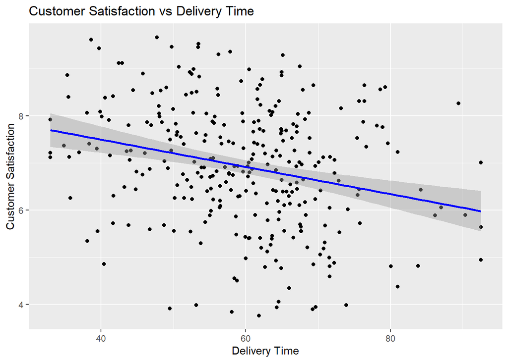

```r
ggplot(cust_data, aes(x = delivery.time, y = customer.satisfaction)) +
  geom_point() +
  geom_smooth(method = "lm", se = TRUE, color = "blue") +
  labs(title = "Customer Satisfaction vs Delivery Time",
       x = "Delivery Time",
       y = "Customer Satisfaction")
```

The results suggest that delivery time is significantly associated with customer satisfaction ($b=-0.03$, $CI=[-0.04,-0.01]$, $t(298)=-4.62$, $p<0.001$). The model indicates that for each additional unit of increase in delivery time, the average customer satisfaction score decrease by 0.03 units.

```r
staff.cust.satis.lm <- lm(staff.satisfaction ~ customer.satisfaction, data = cust_data)
summary(staff.cust.satis.lm)
```

```
##
## Call:
## lm(formula = staff.satisfaction ~ customer.satisfaction, data = cust_data)
##
## Residuals:
##      Min       1Q   Median       3Q      Max
## -1.94991 -0.50195 -0.00034  0.45641  1.76850
##
## Coefficients:
##                       Estimate Std. Error t value Pr(>|t|)
## (Intercept)            4.83617    0.22143  21.841   <2e-16 ***
## customer.satisfaction  0.27636    0.03141   8.797   <2e-16 ***
## ---
## Signif. codes:  0 '***' 0.001 '**' 0.01 '*' 0.05 '.' 0.1 ' ' 1
##
## Residual standard error: 0.7016 on 298 degrees of freedom
## Multiple R-squared:  0.2062, Adjusted R-squared:  0.2035
## F-statistic: 77.39 on 1 and 298 DF,  p-value: < 2.2e-16
```

```r
#confidence interval
confint(staff.cust.satis.lm)
```

```
##                           2.5 %    97.5 %
## (Intercept)           4.4004046 5.2719388
## customer.satisfaction 0.2145337 0.3381771
```

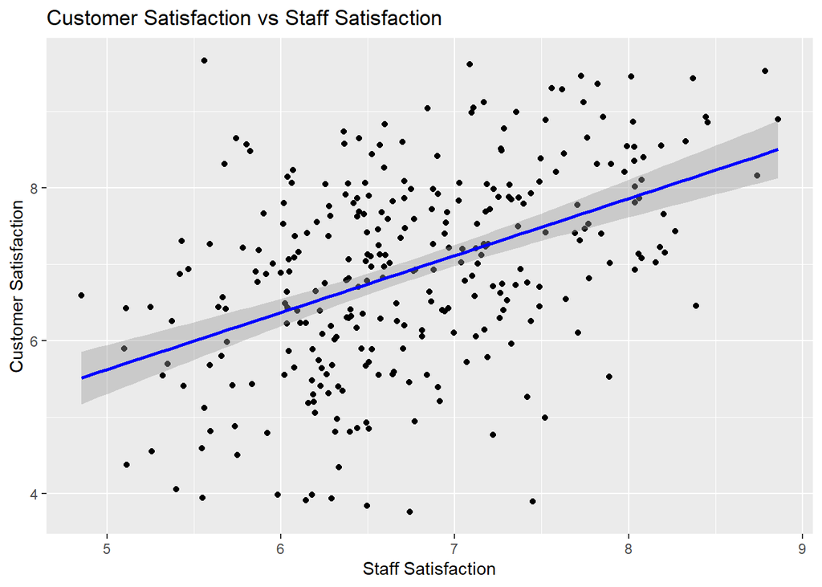

```r
ggplot(cust_data, aes(x = staff.satisfaction, y = customer.satisfaction)) +
  geom_point() +
  geom_smooth(method = "lm", se = TRUE, color = "blue") +
  labs(title = "Customer Satisfaction vs Staff Satisfaction",
       x = "Staff Satisfaction",
       y = "Customer Satisfaction")
```

3. Effect of *SES_Category* on *customer satisfaction*

```r
SES.cust.satis.lm <- lm(customer.satisfaction ~ factor(SES_category) , data = cust_data)
summary(SES.cust.satis.lm)
```

```
##
## Call:
## lm(formula = customer.satisfaction ~ factor(SES_category), data = cust_data)
##
## Residuals:
##      Min       1Q   Median       3Q      Max
## -2.50418 -0.68360 -0.02135  0.69008  2.56582
##
## Coefficients:
##                            Estimate Std. Error t value Pr(>|t|)
## (Intercept)                  6.5542     0.1015  64.604   <2e-16 ***
## factor(SES_category)Low     -0.3639     0.1435  -2.536   0.0117 *
## factor(SES_category)Medium   1.4908     0.1435  10.391   <2e-16 ***
## ---
## Signif. codes:  0 '***' 0.001 '**' 0.01 '*' 0.05 '.' 0.1 ' ' 1
##
## Residual standard error: 1.015 on 297 degrees of freedom
## Multiple R-squared:  0.3872, Adjusted R-squared:  0.3831
## F-statistic: 93.84 on 2 and 297 DF,  p-value: < 2.2e-16
```

```r
#confidence interval
confint(SES.cust.satis.lm)
```

```
##                                 2.5 %      97.5 %
## (Intercept)                 6.3545238  6.75383367
## factor(SES_category)Low    -0.6462444 -0.08153498
## factor(SES_category)Medium  1.2084390  1.77314841
```

Compared to the High SES category, stores in the Low SES category had a predicted customer satisfaction score that was 0.36 units lower ($b=-0.36$, $CI=[-0.65,-0.08]$, $t(297)=-2.5$, $p<0.05$), while those in the Medium SES category had a predicted score that was 1.49 units higher ($b=1.49$, $CI=[1.21,1.77]$, $t(297)=10.4$, $p<0.001$)

Additionally, the intercept ($b=6.55$) represented the customer satisfaction score of the stores in High SES category.

4. Effect of *new range* on *customer satisfaction*

```r
newrange.cust.satis.lm <- lm(customer.satisfaction ~ factor(new_range) , data = cust_data)
summary(newrange.cust.satis.lm)
```

```
##
## Call:
## lm(formula = customer.satisfaction ~ factor(new_range), data = cust_data)
##
## Residuals:
##     Min      1Q  Median      3Q     Max
## -3.2312 -0.8121  0.0499  0.9250  2.8085
##
## Coefficients:
##                       Estimate Std. Error t value Pr(>|t|)
## (Intercept)             6.8615     0.1084  63.276   <2e-16 ***
## factor(new_range)TRUE   0.1298     0.1494   0.868    0.386
## ---
## Signif. codes:  0 '***' 0.001 '**' 0.01 '*' 0.05 '.' 0.1 ' ' 1
##
## Residual standard error: 1.292 on 298 degrees of freedom
## Multiple R-squared:  0.002525,   Adjusted R-squared:  -0.0008227
## F-statistic: 0.7542 on 1 and 298 DF,  p-value: 0.3858
```

```r
#confidence interval
confint(newrange.cust.satis.lm)
```

```
##                            2.5 %    97.5 %
## (Intercept)            6.6480692 7.0748707
## factor(new_range)TRUE -0.1642885 0.4238207
```

- Multiple Linear Regression

Effect of *delivery time* and *SES categories* on *customer satisfaction*

```r
del.SES.lm <- lm(customer.satisfaction ~ delivery.time * SES_category, data = cust_data)
summary(del.SES.lm)
```

```
##
## Call:
## lm(formula = customer.satisfaction ~ delivery.time * SES_category,
##     data = cust_data)
##
## Residuals:
##      Min       1Q   Median       3Q      Max
## -2.43290 -0.63000  0.00057  0.72673  2.52903
##
## Coefficients:
##                                  Estimate Std. Error t value Pr(>|t|)
## (Intercept)                       8.62092    0.57199  15.072  < 2e-16 ***
## delivery.time                    -0.03471    0.00946  -3.669 0.000289 ***
## SES_categoryLow                  -2.12232    0.77457  -2.740 0.006519 **
## SES_categoryMedium                0.29635    0.76383   0.388 0.698310
## delivery.time:SES_categoryLow     0.02976    0.01253   2.374 0.018221 *
## delivery.time:SES_categoryMedium  0.01937    0.01287   1.505 0.133336
## ---
## Signif. codes:  0 '***' 0.001 '**' 0.01 '*' 0.05 '.' 0.1 ' ' 1
##
## Residual standard error: 0.9916 on 294 degrees of freedom
## Multiple R-squared:  0.4205, Adjusted R-squared:  0.4107
## F-statistic: 42.67 on 5 and 294 DF,  p-value: < 2.2e-16
```

```r
#confidence interval
confint(del.SES.lm)
```

```
##                                         2.5 %      97.5 %
## (Intercept)                       7.495216637  9.74663269
## delivery.time                    -0.053323742 -0.01608879
## SES_categoryLow                  -3.646725172 -0.59792116
## SES_categoryMedium               -1.206919224  1.79962687
## delivery.time:SES_categoryLow     0.005092879  0.05443078
## delivery.time:SES_categoryMedium -0.005956578  0.04470155
```

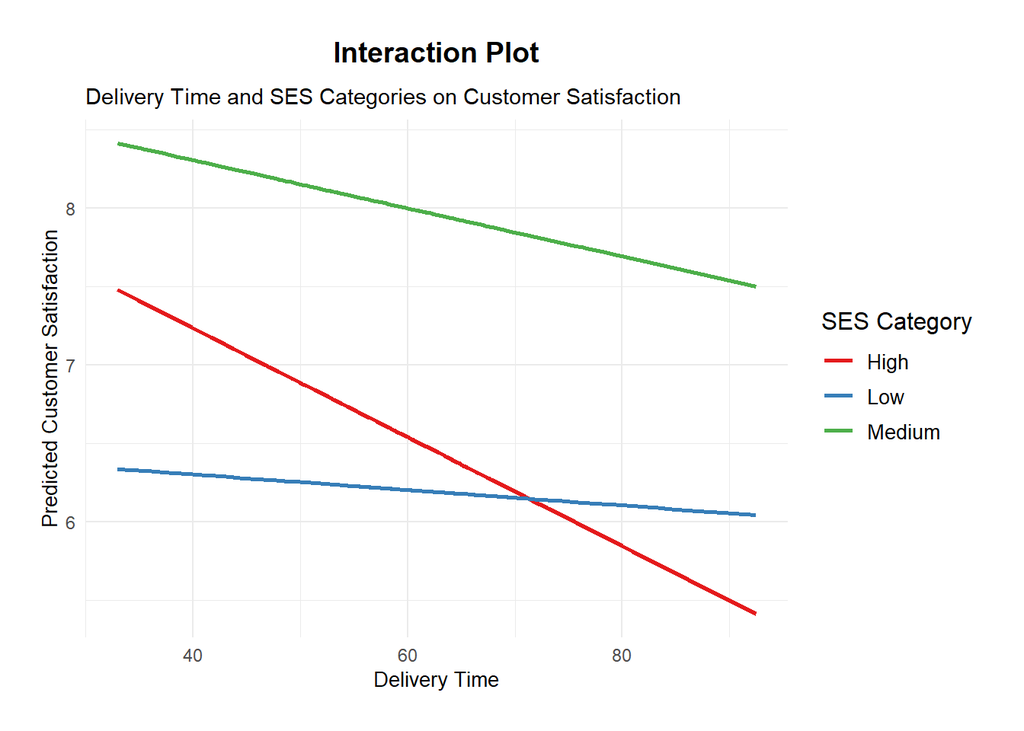

```r
# Generate predictions using the regression model
cust_data$predicted_satisfaction <- predict(lm(customer.satisfaction ~ delivery.time * SES_category, data = cust_data))

# Create the interaction line plot
ggplot(cust_data, aes(x = delivery.time, y = predicted_satisfaction, color = SES_category)) +
  geom_line(size = 1) +
  labs(
    title = "Interaction Plot",
    subtitle = "Delivery Time and SES Categories on Customer Satisfaction",
    x = "Delivery Time",
    y = "Predicted Customer Satisfaction",
    color = "SES Category"
  ) +
  theme_minimal() +
  theme(
    plot.title = element_text(hjust = 0.5, size = 14, face = "bold", margin = margin(b = 10)),
    axis.title = element_text(size = 10),
    legend.title = element_text(size = 12),
    legend.text = element_text(size = 10),
    plot.margin = margin(t = 20, r = 20, b = 20, l = 20, unit = "pt")
  ) +
  scale_color_brewer(palette = "Set1")
```

This figure shows the interaction between `delivery.times` and `SES_category` across *predicted customer satisfaction*. While all areas experience declining satisfaction with longer delivery times, the impact varies. Stores in High SES areas are more prone to delays, followed by stores in Medium SES areas. Notably, delivery time has minimal influence on predicted customer satisfaction scores in Low SES areas, suggesting their expectations may differ regarding delivery speed.